# 3. Rules of Derivative

Cheng Peng

West Chester University

# 1 Review: Basic Rules of Derivative

We defined the derivaive of a function $y = f(x)$, denoted by $y^\prime = f^\prime(x)$, to be instantaneous rate of change
$$f^\prime(x) = \lim_{h \to 0}\frac{f(x+h)-f(x)}{h}$$

The following basic rules were also introduced to calculate derivatives easier.

1. $f(x) = c$, then $f^\prime(x) = (c)^\prime = 0$.
2. $f(x) = x$, then $f^\prime(x) = (x)^\prime = 1$.
3. $f(x) = x^a$, then $f^\prime(x) = (x^a)^\prime = ax^{a-1}$. for any real number $a$.

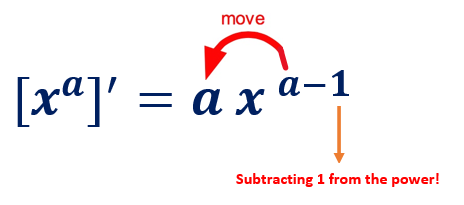

Properties:

1. $[bf(x)]^\prime = b[f(x)]^\prime$
2. $[f(x) + g(x)]^\prime = [f(x)]^\prime + [g(x)]^\prime$

We will continue to introduce more rules and properties of derivatives this week.

# 2 Leibniz Notation

In calculus, **Leibniz’s notation** uses the symbols $dx$ and $dy$ to represent infinitely small (or infinitesimal) increments of $x$ and $y$, respectively, just as $\Delta x$ and $\Delta y$ represent finite increments of $x$ and $y$, respectively.

Consider $y$ as a function of a variable $x$, or $y = f(x)$. If this is the case, then the derivative of $y$ with respect to $x$, which later came to be viewed as the limit

$$\lim_{{\Delta x\rightarrow 0}}{\frac {\Delta y}{\Delta x}}=\lim_{{\Delta
x\rightarrow 0}}{\frac {f(x+\Delta x)-f(x)}{\Delta x}},$$

was, according to Leibniz, the quotient of an **infinitesimal increment** of $y$ by an **infinitesimal increment** of $x$, or

$$\frac{dy}{dx}=f^\prime(x),$$

The **infinitesimal increments** are called **differentials**. From now on, we will use the following notations interchangeably.

$$\frac{d f(x)}{dx} \text{ , } \frac{d}{dx}f(x), \text{ , and } f^\prime
(x)$$

# 3 Multiplicative Rule

If a function that has a complex form can be re-expressed into a product of two relatively simple functions, then we can use the **multiplicative rule** to find the derivative.

Let $f(x)$ and $g(x)$ be the two differentiable functions (i.e., the derivative of both functions exists everywhere in the domain).

$$\frac{d}{dx}[f(x)g(x)] = f^\prime(x) g(x) + f(x) g^\prime(x)$$

[figure not shown]

**Example 1**: Find the derivative of the following function.

(a). $y = \sqrt[3]{x^2}(2x - x^2)$

(b). $y = (6x^3 - x)(10 - 20x)$

**Solution** We use the multiplicative rule to calculate the above derivative.

(a). $y^\prime = [x^{2/3}(2x - x^2)]^\prime = (x^{2/3})^\prime(2x - x^2) + x^{2/3}(2x - x^2)^\prime$
$$= \frac{2}{3}x^{2/3-1}(2x-x^2) + x^{2/3}(2 - 2x)
=\frac{2}{3}x^{-1/3}(2x-x^2)+x^{2/3}(2 - 2x)$$
$$=\frac{2}{3}x^{2/3}(2-x) + 2x^{2/3}(1 - x) = 2x^{2/3}[(2-x)/3+1 - x]$$

$$= 2x^{2/3}\frac{2-x+3(1-x)}{3}=\frac{2x^{2/3}(5-4x)}{3}$$

(b). $y^\prime = [(6x^3 - x)(10 - 20x)]^\prime = (6x^3 - x)^\prime(10 - 20x) + (6x^3 - x)(10 - 20x)^\prime$

$= (18x^2 - x)(10 - 20x) + (6x^3 - x)\times (-20) = -480x^3+180x^2+40x-10$

**Example 2**: (This example is taken from the textbook)

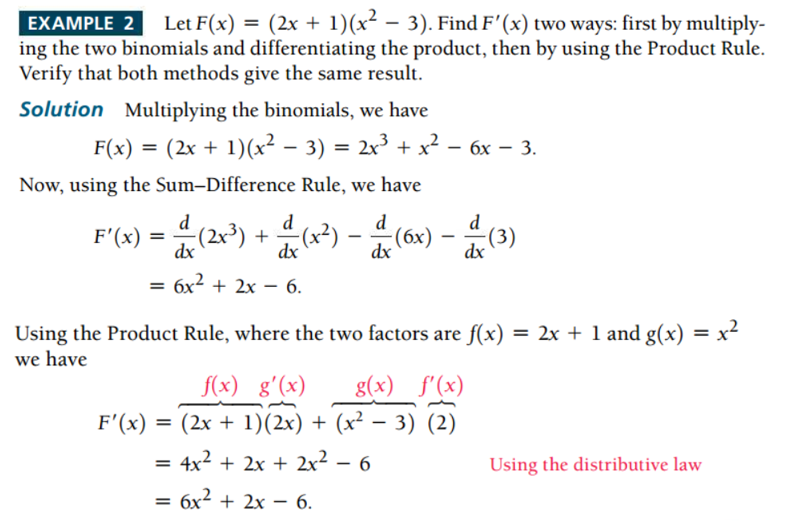

# 4 Quotient Rule

The quotient rule can be used for differentiation when taking the derivative of a function divided by another function. For example, rational functions are this type of question.

Let $f(x)$ and $g(x)$ be two differentiable functions. The quotient rule of the derivative is given in the following.

$$\frac{d}{dx} \left(\frac{f(x)}{g(x)}\right) = \frac{f^\prime(x)g(x) -
f(x)g^\prime(x)}{g^2(x)}$$

The following animated graph shows how to manipulate the terms algebraically.

[figure not shown]

**Example 3**. Find the derivative of the following functions.

(a). $W(z) = (3z + 9)/(2 -z)$

(b). $h(x) = 4\sqrt{x}/(x^2 - 2)$

**Solution**: Using the quotient rule, we have

(a). $W^\prime(z) = [(3z+9)^\prime(2-z) - (3z+9)(2-z)^\prime]/(2-z)^2$
$$= \frac{3(2-z)-(3z+9)(-1)}{(2-z)^2} = \frac{15}{(2-z)^2}$$

(b). $y^\prime = \left[(4\sqrt{x})^\prime (x^2-2) -(4\sqrt{x})(x^2-2)^\prime\right]/(x^2-2)^2$
$$= \frac{(2/\sqrt{x})(x^2-2)-8x\sqrt{x}}{(x^2-2)^2} =
-\frac{6x\sqrt{x}+4/\sqrt{x}}{(x^2-2)^2}.$$

**Example 4** (This example is taken from the textbook)

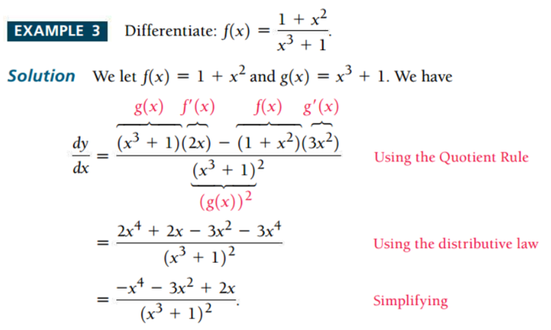

**Important Business Functions**: Cost, Revenue, and Profit-related functions and applications.

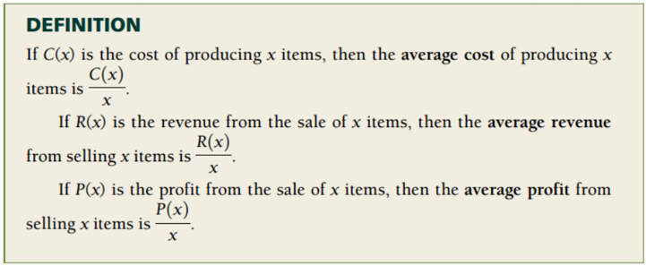

**Example 5** (This example is also taken from the textbook)

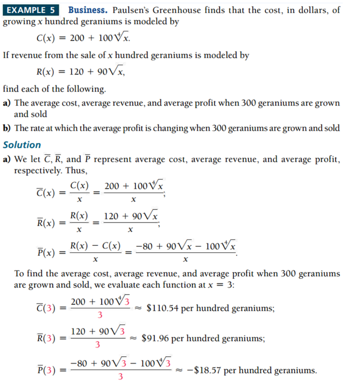

# 5 Chain Rule

Before introducing the Chain Rule, we first review the definition of a composite function.

## 5.1 Composite Function

Suppose the two given functions are $f$ and $g$, the composition of $f$ and $g$, denoted by $f\circ g$, is given by

$$f\circ g (x) = f(g(x)) \ \ \ \text{ and } \ \ \ \ g\circ f (x)
= g(f(x))$$

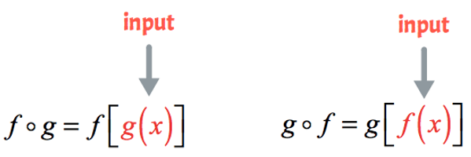

**Example 6** Let $f(x) = 2x^2 - 3x -1$ and $g(x) = -x + 5$. Find $f\circ g$.

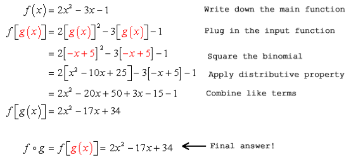

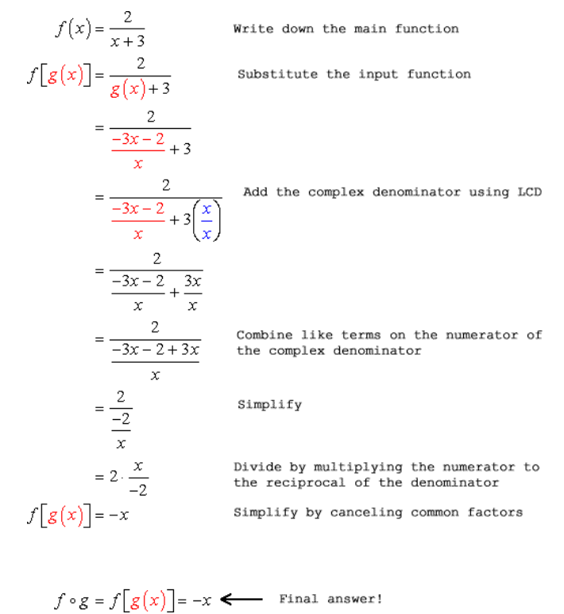

## 5.2 Chain Rule

The following Chain Rule is used to find the derivative of composite functions.

$$[f(g(x))]^\prime = f^\prime(g(x)) \times g^\prime(x)$$

[figure not shown]

**Example 8** Find the derivative of the following function
$$f(x) = \sqrt[4]{\frac{x + 3}{x - 2}}.$$

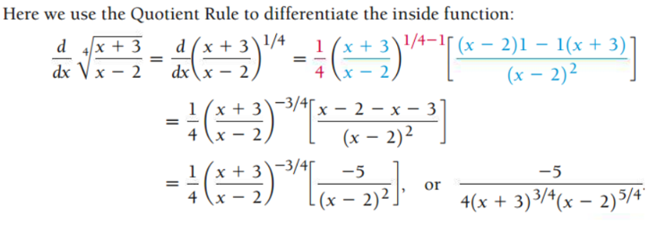

**Example 9**: Find the derivative of $f(x) = \sqrt[3]{x^5 + 6x}$.